# EDA_LA_2

# Making a Dot Plot

```r
# Save a modified data set that only includes of males data for marks that contains > 50
data7 <- df %>%
filter(gender == "Male" & pretest > 50)
```

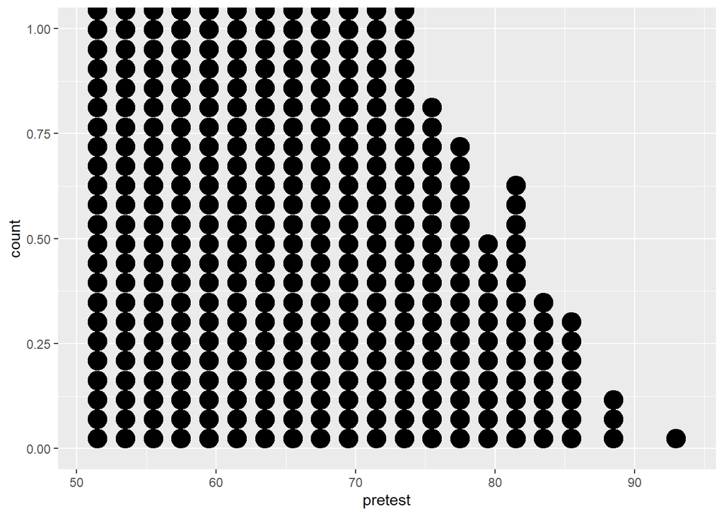

```r
# Create a base ggplot object using `data7`, called `data7_p` (for data7 plot)
data8 <- ggplot(data7,aes(x=pretest))
data8+geom_dotplot()
```

# Dot plot with stackdir = “center” (1) # With stackdir = “centerwhole”(2)

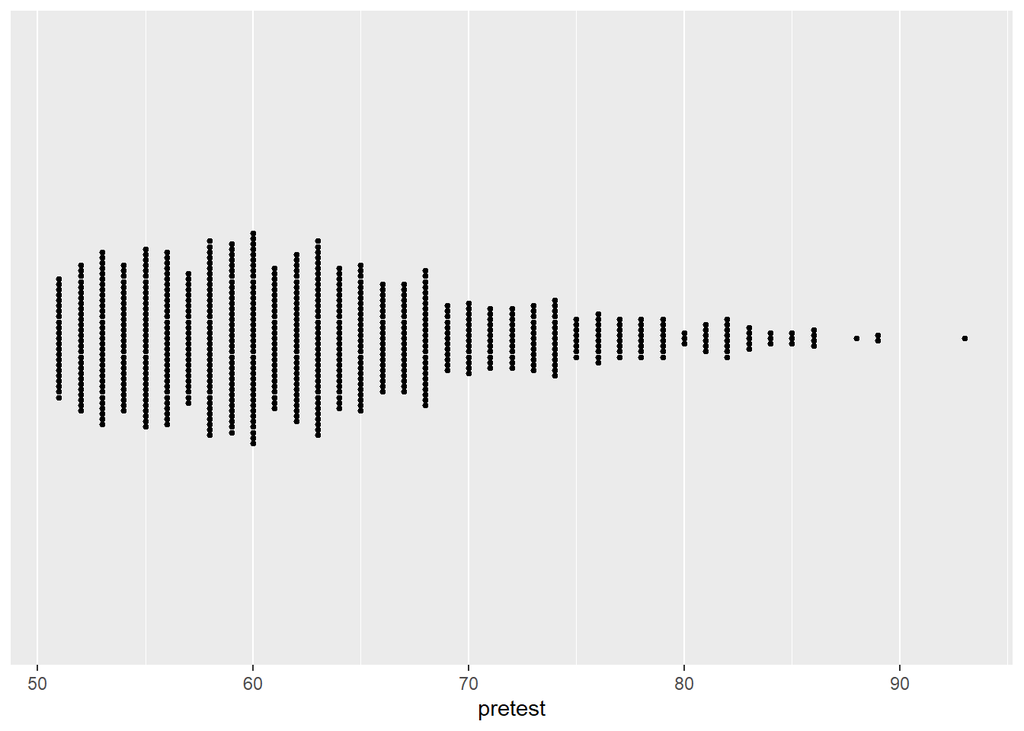

```r
data8 +
geom_dotplot(binwidth = .25, stackdir = "center") +
scale_y_continuous(breaks = NULL) +
theme(axis.title.y = element_blank())
```

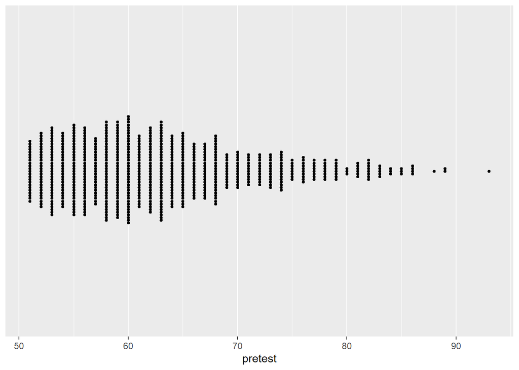

```r
data8 +
geom_dotplot(binwidth = .25, stackdir = "centerwhole") +
scale_y_continuous(breaks = NULL) +
theme(axis.title.y = element_blank())
```

# Making Multiple Dot Plots for Grouped Data

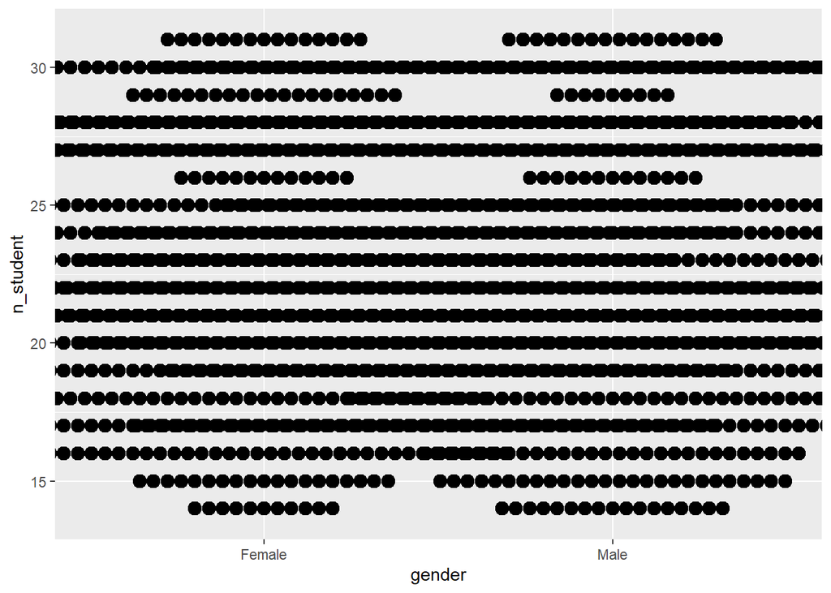

```r
ggplot(df, aes(x = gender, y = n_student)) +
geom_dotplot(binaxis = "y", binwidth = .5, stackdir = "center")
```

# Dot plot overlaid on box plot

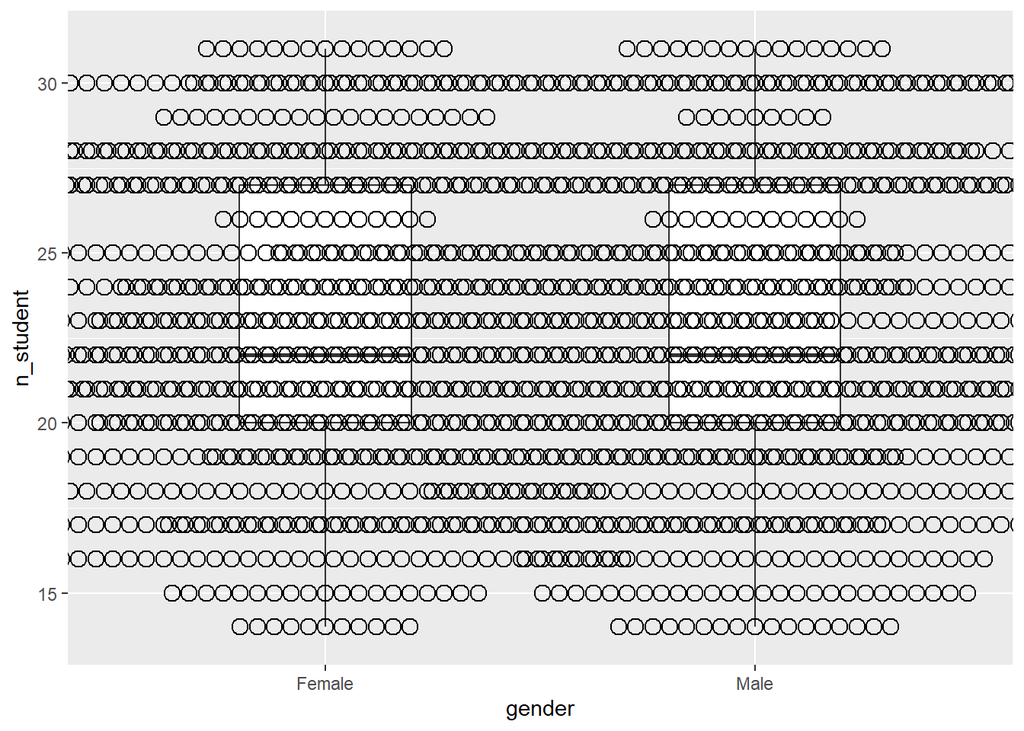

```r
ggplot(df, aes(x = gender, y = n_student)) +
geom_boxplot(outlier.colour = NA, width = .4) +
geom_dotplot(binaxis = "y", binwidth = .5, stackdir = "center", fill = NA)
```

# Dot plot next to box plot

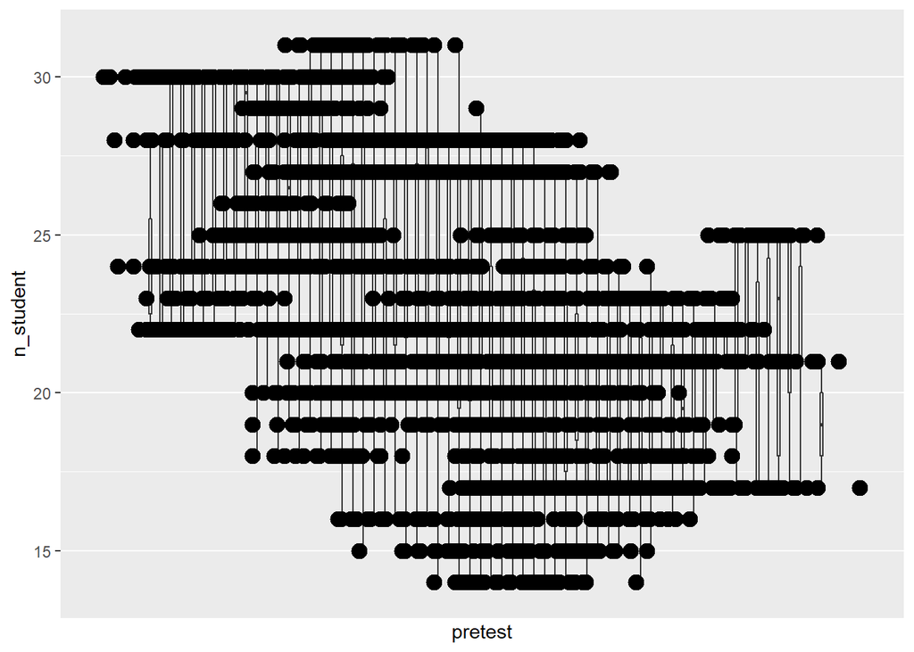

```r
ggplot(df, aes(x = pretest, y = n_student)) +
geom_boxplot(aes(x = as.numeric(pretest) + .2, group = pretest), width = .25) +geom_dotplot(aes(x = as.numeric(pretest) - .2, group = pretest),binaxis = "y",binwidth = .5,stackdir = "center") +scale_x_continuous(breaks = 1:nlevels(df$pretest),labels=levels(df$pretest)
)
```

# Making a Density Plot of Two-Dimensional Data

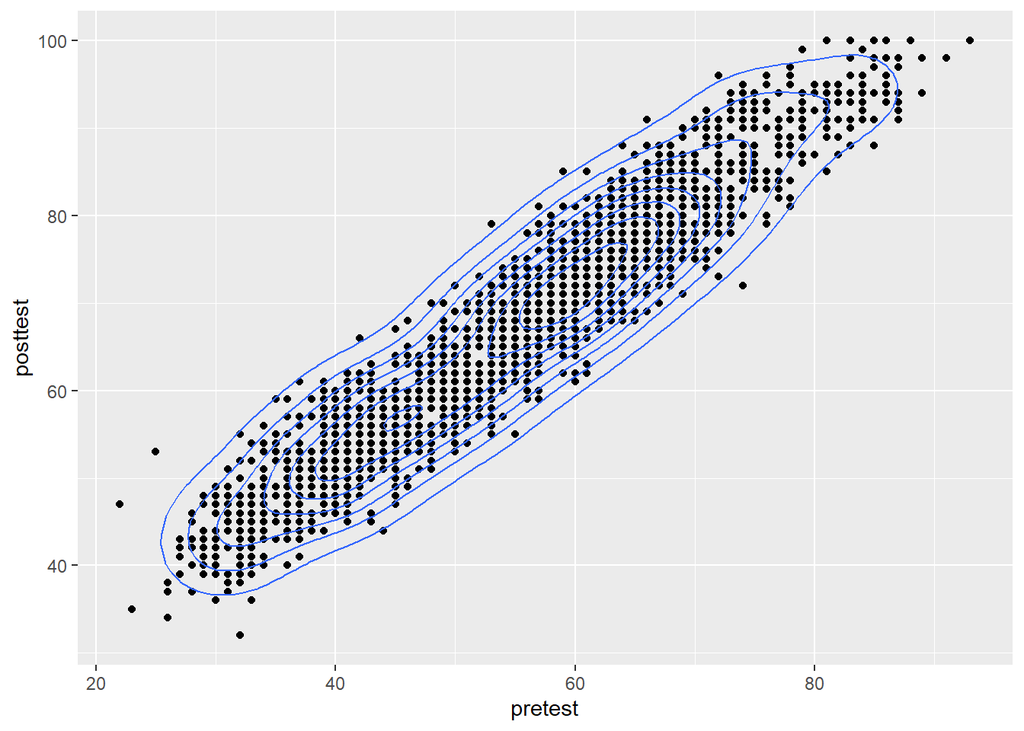

```r
# Save a base plot object
 ggplot(df, aes(x = pretest, y = posttest))+geom_point() +stat_density2d()
```

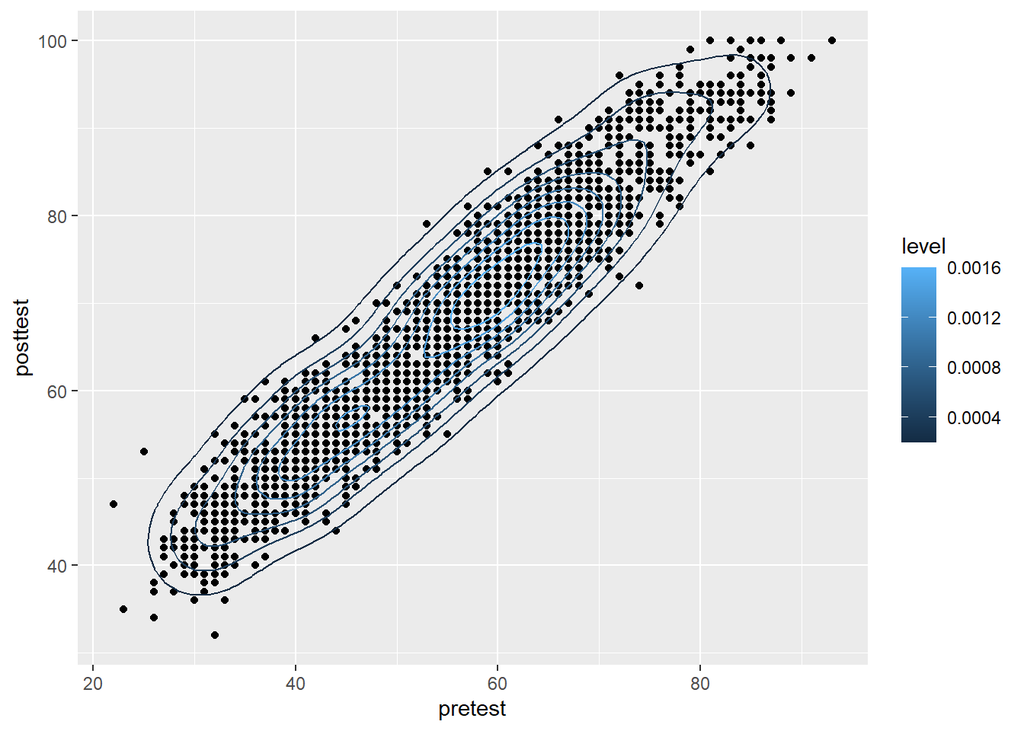

```r
# Contour lines, with "height" mapped to color
ggplot(df, aes(x = pretest, y = posttest))+geom_point() +stat_density2d()+stat_density2d(aes(colour = ..level..))
```

# With ..density.. mapped to fill (1) # With points, and ..density.. mapped to alpha(2)

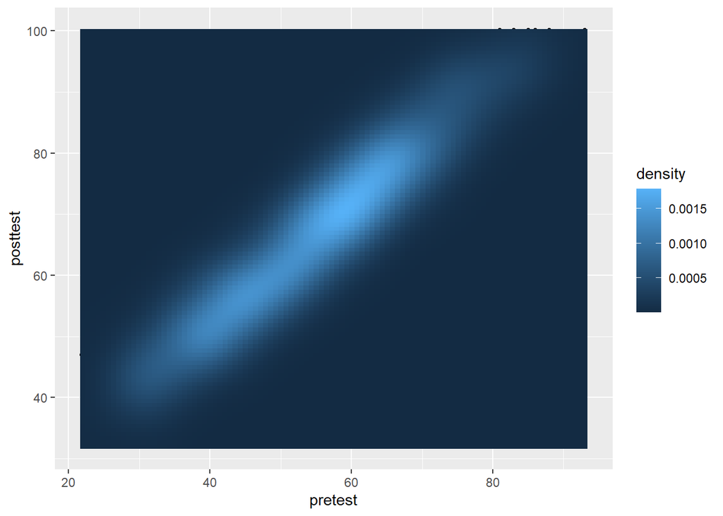

```r
# Map density estimate to fill color
ggplot(df, aes(x = pretest, y = posttest))+geom_point() +stat_density2d()+stat_density2d(aes(fill = ..density..), geom = "raster", contour = FALSE)
```

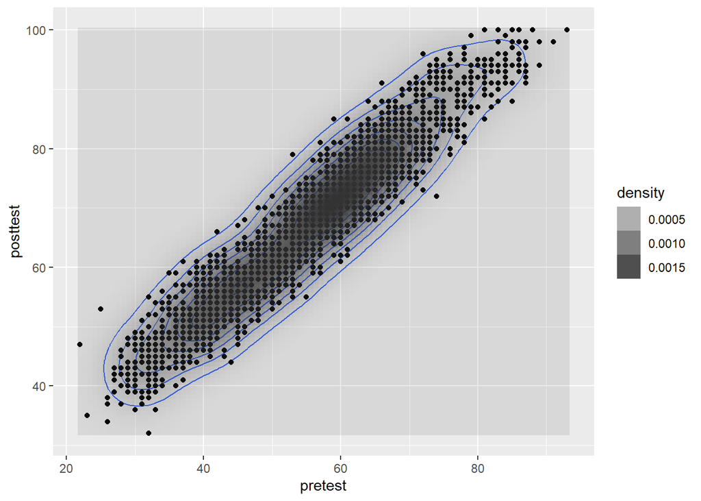

```r
# With points, and map density estimate to alpha
ggplot(df, aes(x = pretest, y = posttest))+geom_point() +stat_density2d()+geom_point() +stat_density2d(aes(alpha = ..density..), geom = "tile", contour = FALSE)
```

# Plotting a Function # # The data frame is only used for setting the range

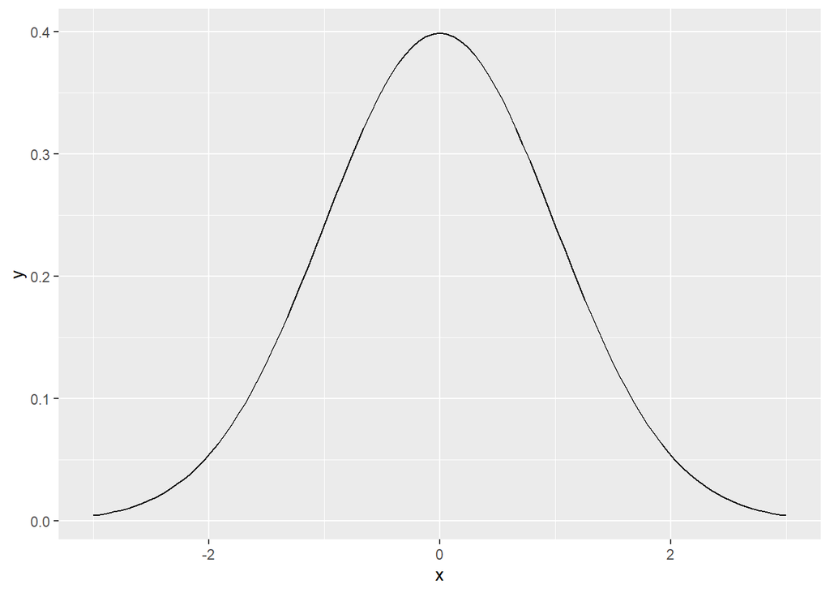

```r
# The normal distribution
ggplot(data.frame(x = c(-3, 3)), aes(x = x))  + stat_function(fun = dnorm)
```

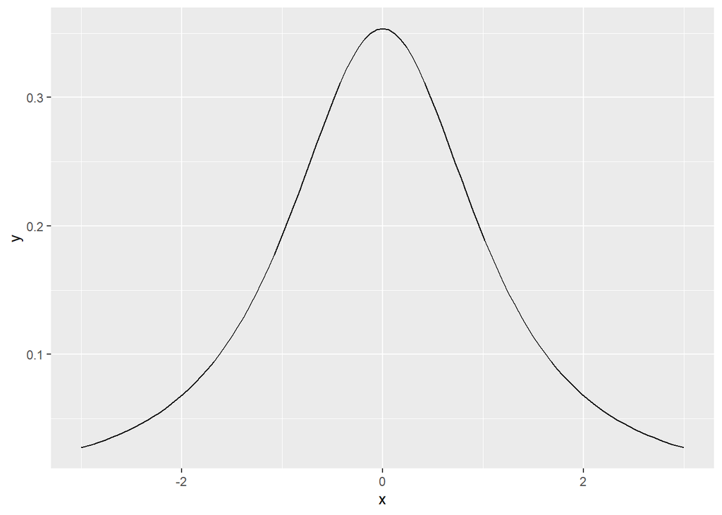

```r
# The t-distribution with df=2
ggplot(data.frame(x = c(-3, 3)), aes(x = x)) + stat_function(fun = dt, args = list(df = 2))
```